# Predicting Dumbbell Biceps Curl Form Using Machine Learning Models

### Coursera Practical Machine Learning Course Project

## Synopsis

Quantitative activity recognition can be used to determine how well an activity or exercise was performed. Data from the study “Quantitative Activity Recognition of Weight Lifting Exercises” was used to build a random forest model to predict whether a dumbbell biceps curl was being performed correctly or if a common mistake was being made based on full body motion measurements taken during the exercise. The training data was split into a “training” (70%) and “testing” (30%) data set. The random forest model had an accuracy greater than 0.99 compared to the testing set and was then compared to a validation set with 20 samples. Looking at the importance of each variable, some variables such as “roll belt,” “yaw belt,” “pitch forearm,” and “roll forearm” were much more important than others, indicating that some sensor readings were much more valuable than others when predicting the form that was used.

## Introduction

Activity trackers on the market today can be used to determine how much of a particular activity/exercise the user is performing, but doesn’t necessarily tell anything about how well the activity was performed, which could impact the effectiveness of the exercise and the likelihood of injury. Qualitative activity recognition focuses on how well an activity or exercise was performed. Using machine learning models, study data can be used to predict when an activity is being performed correctly or if the user is making a common mistake. The purpose of this analysis is to predict the correct exercise form and common mistakes users make when performing the dumbbell biceps curl. This analysis is based on data and work done in the study “Quantitative Activity Recognition of Weight Lifting Exercises”:

**Velloso, E.; Bulling, A.; Gellersen, H.; Ugulino, W.; Fuks,H. Qualitative Activity Recognition of Weight Lifting Exercises. Proceedings of 4th International Conference in Cooperation with SIGCHI (Augmented Human ’13). Stuttgart, Germany: ACM SIGCHI, 2013. Available at http://groupware.les.inf.puc-rio.br/work.jsf?p1=11201**

The study looked at the correct dumbbell biceps curl form as well as four common mistakes:

- Class A: Correct form
- Class B: Elbows thrown to front
- Class C: Dumbbell lifted halfway
- Class D: Dumbbell lowered halfway
- Class E: Hips thrown to front

Using training data from the study, we can use a machine learning model to predict the correct class in a testing and validation data set.

## Data Processing

For this analysis, the data used in this study is broken into a “training” and “testing” set (which is used as a validation set):

- Training Data Set: https://d396qusza40orc.cloudfront.net/predmachlearn/pml-training.csv
- Validation Data Set: https://d396qusza40orc.cloudfront.net/predmachlearn/pml-testing.csv

The first step in processing the data is to download the data, subset the appropriate columns, and load the libraries used in the analysis. Training data is downloaded from the link above, placed in the working directory, and then loaded into R using the read.csv() function. The data is then subset, removing bookkeeping columns such as row number, window number, and timestamp columns. Columns that have no data in the “pml-testing.csv” data set are also removed, since keeping them in the training set would have no predictive power (e.g., kurtosis, min, max, and ampliture columns). Altogether, 53 of 160 total variables are kept in the data set. The libraries “caret” and “randomForest” are used in this analysis.

```r
data <- read.csv("./pml-training.csv")
dataClean <- data[,c(8:11,37:49,60:68,84:86,102,113:124,140,151:159,160)]
str(dataClean)
```

```
## 'data.frame':    19622 obs. of  53 variables:
##  $ roll_belt           : num  1.41 1.41 1.42 1.48 1.48 1.45 1.42 1.42 1.43 1.45 ...
##  $ pitch_belt          : num  8.07 8.07 8.07 8.05 8.07 8.06 8.09 8.13 8.16 8.17 ...
##  $ yaw_belt            : num  -94.4 -94.4 -94.4 -94.4 -94.4 -94.4 -94.4 -94.4 -94.4 -94.4 ...
##  $ total_accel_belt    : int  3 3 3 3 3 3 3 3 3 3 ...
##  $ gyros_belt_x        : num  0 0.02 0 0.02 0.02 0.02 0.02 0.02 0.02 0.03 ...
##  $ gyros_belt_y        : num  0 0 0 0 0.02 0 0 0 0 0 ...
##  $ gyros_belt_z        : num  -0.02 -0.02 -0.02 -0.03 -0.02 -0.02 -0.02 -0.02 -0.02 0 ...
##  $ accel_belt_x        : int  -21 -22 -20 -22 -21 -21 -22 -22 -20 -21 ...
##  $ accel_belt_y        : int  4 4 5 3 2 4 3 4 2 4 ...
##  $ accel_belt_z        : int  22 22 23 21 24 21 21 21 24 22 ...
##  $ magnet_belt_x       : int  -3 -7 -2 -6 -6 0 -4 -2 1 -3 ...
##  $ magnet_belt_y       : int  599 608 600 604 600 603 599 603 602 609 ...
##  $ magnet_belt_z       : int  -313 -311 -305 -310 -302 -312 -311 -313 -312 -308 ...
##  $ roll_arm            : num  -128 -128 -128 -128 -128 -128 -128 -128 -128 -128 ...
```

[output cut: 39 more lines]

Next, using the carat package, the training data is split into a “training” (70%) and “testing” (30%) set, so that the randomForest model can be tested on the test set before being used on the validation set (which should only be used once).

```r
inTrain <- createDataPartition(y=dataClean$classe, p=0.70, list=FALSE)
training <- dataClean[inTrain,]
testing <- dataClean[-inTrain,]
```

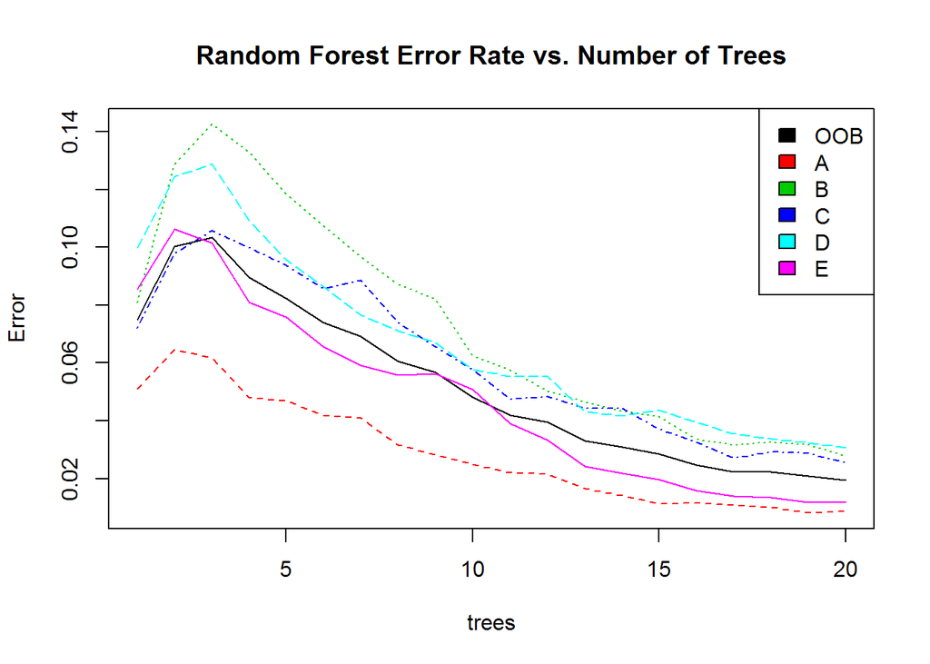

```r
set.seed(1000)
rf <- randomForest(classe ~ ., data=training, type="prob", ntree=20, nodesize=5, NA.rm=TRUE)
plot(rf, main="Random Forest Error Rate vs. Number of Trees")
legend("topright",colnames(rf$err.rate),col=1:6,fill=1:6)
```

## Results

The accuracy of the random forest model is predicted by comparing the results to the testing set (30%) that was split at the beginning of the analysis using the predict() function. After that, the confusionMatrix() function is used to calculate the accuracy of the model.

```r
set.seed(1000)
predTesting <- predict(rf,newdata=testing)
testAccuracy <- confusionMatrix(predTesting,testing$classe)
testAccuracy
```

```
## Confusion Matrix and Statistics
##
##           Reference
## Prediction    A    B    C    D    E
##          A 1668    3    0    0    0
##          B    6 1132   11    0    2
##          C    0    4 1010   17    2
##          D    0    0    5  946    3
##          E    0    0    0    1 1075
##
## Overall Statistics
##
##                Accuracy : 0.9908
##                  95% CI : (0.988, 0.9931)
##     No Information Rate : 0.2845
##     P-Value [Acc > NIR] : < 2.2e-16
##
##                   Kappa : 0.9884
##  Mcnemar's Test P-Value : NA
##
## Statistics by Class:
##
##                      Class: A Class: B Class: C Class: D Class: E
## Sensitivity            0.9964   0.9939   0.9844   0.9813   0.9935
## Specificity            0.9993   0.9960   0.9953   0.9984   0.9998
## Pos Pred Value         0.9982   0.9835   0.9777   0.9916   0.9991
## Neg Pred Value         0.9986   0.9985   0.9967   0.9963   0.9985
## Prevalence             0.2845   0.1935   0.1743   0.1638   0.1839
## Detection Rate         0.2834   0.1924   0.1716   0.1607   0.1827
## Detection Prevalence   0.2839   0.1956   0.1755   0.1621   0.1828
## Balanced Accuracy      0.9979   0.9949   0.9898   0.9899   0.9967
```

Predicting the test set, we see that the random forest model has an accuracy of 0.9908241, which gives an out-of-sample error rate of 0.0091759. The final step in the analysis is comparing the random forest model to the validation test set to predict the values of 20 samples with an unknown exercise class. The model predicts the following classes for the samples found here: https://d396qusza40orc.cloudfront.net/predmachlearn/pml-testing.csv

```r
validation <- read.csv("./pml-testing.csv")
predValidation <- predict(rf,newdata=validation)
predValidation
```

```
##  1  2  3  4  5  6  7  8  9 10 11 12 13 14 15 16 17 18 19 20
##  B  A  B  A  A  E  D  B  A  A  B  C  B  A  E  E  A  B  B  B
## Levels: A B C D E
```

## Discussion/Conclusion

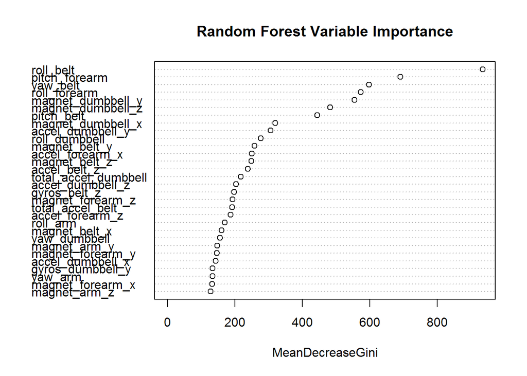

```r
varImpPlot(rf, main="Random Forest Variable Importance")
```

In order to use quantitative activity recognition on a larger scale and with more activities, additional data collection and more in-depth analysis would need to be done to determine what common mistakes are for a wide range of activities and activity trackers with additional sensors would need to be developed to track full body motion. However, studies such as these would be useful for building more advanced activity trackers since alerting the user to poor form could help improve the effectiveness of the activitiy and also reduce the risk of injury.